# Ensemble_techniques_machine_learning

## Background

The dataset is covering some information about 72 samples of Honey collected From Lebanon by the UNDP (UNITED NATIONS ORGANIZATION) and LARI (LEBANESE AGRICULTURAL RESEARCH INSTITUTE) and compiled by the ABU (ARAB BEEKEEPERS UNION), a group of members that has organized Honey tasting events.

Each honey sample is provided to us with its name, its beekeeper name, the year of collection, the region, the botanical origin, and the sensory rating. For my thesis work in 2019, I tested the physicochemical properties of each sample, which were added to this dataset.

- 5 = Elite (Transcending beyond the ordinary limits)
- 4 = Premium (Superior quality)
- 3 = Satisfactory (3.0) to praiseworthy (3.75)
- 2 = Passable (but contains at least one significant flaw)
- 1 = Unpleasant

Since the quality of honey is affected by the botanical origin and the physicochemical properties, honey companies need a predictive model that can distinguish the premium honey quality based on past data, instead of conducting sensory analysis and hiring panels.

## Objectives

Looking ahead, of interest in this project will be to build a model that predicts the quality of honey samples.

## Data Description

- Name: name of each honey sample under the format (H-number of the sample)
- Beekeeper: name of the beekeeper
- Year: year of honey sample collection
- Region: city or village name where a honey sample is collected from
- Botanical origin: the botanical origin of the sample
- Electrical conductivity: physiochemical property
- Refractive index: physiochemical property of the honey samples
- Water content: physiochemical property of the honey samples
- Sensory rating: according to ABU rating system.

## Importing Libraries

```python
# Library to suppress warnings or deprecation notes
import warnings
warnings.filterwarnings('ignore')

# Libraries to help with reading and manipulating data
import numpy as np
import pandas as pd

# Libraries to help with data visualization
import matplotlib.pyplot as plt
%matplotlib inline
import seaborn as sns

# Libraries to split data, impute missing values
from sklearn.model_selection import train_test_split
from sklearn.impute import SimpleImputer

# Libraries to import decision tree classifier and different ensemble classifiers
from sklearn.ensemble import BaggingClassifier
from sklearn.ensemble import RandomForestClassifier
from sklearn.ensemble import AdaBoostClassifier, GradientBoostingClassifier
from xgboost import XGBClassifier
from sklearn.ensemble import StackingClassifier
from sklearn.tree import DecisionTreeClassifier

# Libtune to tune model, get different metric scores
from sklearn import metrics
from sklearn.metrics import confusion_matrix, classification_report, accuracy_score, precision_score, recall_score, f1_score
from sklearn.model_selection import GridSearchCV
```

## Reading the Dataset

```python
Honey = pd.read_csv('Honey properties.csv')
```

```python
# copying data to another varaible to avoid any changes to original data
data = Honey.copy()
```

### Viewing the first and last 5 rows of the dataset

```python
data.head()
```

|  | Name | Beekeeper | Year | Region | Botanical origin | Electrical conductivity | Refractive index | Water content | Sensory rating |
| --- | --- | --- | --- | --- | --- | --- | --- | --- | --- |
| 0 | H10 | Ali Nizar Jammoul | 2017.0 | aazzah | NaN | 981.0 | 1.50 | 15.46 | 4.0 |
| 1 | H4 | Samir Hussein Koussan | 2012.0 | Al tibe, marjeyoun | NaN | 330.0 | 1.48 | 20.52 | 1.0 |
| 2 | H12 | Mhamad hassan korrat ali | 2014.0 | NaN | Oak Trees | 1000.0 | 1.49 | 16.27 | 3.0 |
| 3 | H14 | Ali Abd al jalil Saleh | 2014.0 | Al lawza | Oak Trees, Flowers and Thorns | 236.0 | 1.50 | 15.26 | 3.0 |
| 4 | H19 | Ali Dib Youssef | 2017.0 | Ham | NaN | 212.0 | 1.50 | 14.75 | 4.0 |

```python
data.tail()
```

|  | Name | Beekeeper | Year | Region | Botanical origin | Electrical conductivity | Refractive index | Water content | Sensory rating |
| --- | --- | --- | --- | --- | --- | --- | --- | --- | --- |
| 67 | H102 | Fawaz Bahij Sassine | 2017.0 | Kfarzabad | Flowers and Thorns | 459.0 | 1.50 | 15.21 | 3.0 |
| 68 | H105 | Abbas Hussein Jomaa | 2016.0 | Al Kfour | Flowers and Thorns | 443.0 | 1.49 | 16.22 | 3.5 |
| 69 | H110 | Nazih Al Bitar | 2017.0 | Rachaya Al Wadi | Orange blossoms | 450.0 | NaN | NaN | 3.7 |
| 70 | H113 | Aadnan Salameh | 2016.0 | Al Khyam | Kina, Thyme | 532.0 | 1.50 | 15.60 | 3.8 |
| 71 | H115 | Hani Amer | 2018.0 | Al Khalwat | Thorns | NaN | NaN | NaN | 3.0 |

### Shape of dataset

```python
data.shape
```

```
(72, 9)
```

**Observation:**

- The dataset consists of 72 observations or rows and 9 variables or columns.

### Checking data types

```python
data.info()
```

```
<class 'pandas.core.frame.DataFrame'>
RangeIndex: 72 entries, 0 to 71
Data columns (total 9 columns):
 #   Column                   Non-Null Count  Dtype
---  ------                   --------------  -----
 0   Name                     72 non-null     object
 1   Beekeeper                72 non-null     object
 2   Year                     71 non-null     float64
 3   Region                   53 non-null     object
 4   Botanical origin         42 non-null     object
 5   Electrical conductivity  61 non-null     float64
 6   Refractive index         62 non-null     float64
 7   Water content            62 non-null     float64
 8   Sensory rating           70 non-null     float64
dtypes: float64(5), object(4)
memory usage: 5.2+ KB
```

**Observation:**

- 4 variables (Name,Beekeeper,Region,Botanical origin) are objects and the other 5 variables are floats
- All the object type variables can be changed to categories to reduce the data space required to store the dataframe
- Some features have missing values

### Checking for missing values

```python
data.isnull().sum()
```

```
Name                        0
Beekeeper                   0
Year                        1
Region                     19
Botanical origin           30
Electrical conductivity    11
Refractive index           10
Water content              10
Sensory rating              2
dtype: int64
```

**Observation:**

- All variables have missing values except for Name and Beekeeper

### Summary of numerical features

```python
data.describe().T
```

|  | count | mean | std | min | 25% | 50% | 75% | max |
| --- | --- | --- | --- | --- | --- | --- | --- | --- |
| Year | 71.0 | 2015.014085 | 2.258273 | 2010.00 | 2013.0000 | 2015.00 | 2017.0000 | 2018.00 |
| Electrical conductivity | 61.0 | 640.868852 | 344.806007 | 136.00 | 400.0000 | 530.00 | 934.0000 | 1411.00 |
| Refractive index | 62.0 | 1.494516 | 0.005917 | 1.48 | 1.4900 | 1.49 | 1.5000 | 1.51 |
| Water content | 62.0 | 16.657419 | 1.639142 | 12.39 | 15.4825 | 16.38 | 17.6225 | 20.52 |
| Sensory rating | 70.0 | 2.500000 | 1.177814 | 1.00 | 1.2500 | 2.25 | 3.0000 | 5.00 |

**Observation:**

### Summary of the categorical features

```python
data.describe(include=["object"])
```

|  | Name | Beekeeper | Region | Botanical origin |
| --- | --- | --- | --- | --- |
| count | 72 | 72 | 53 | 42 |
| unique | 72 | 63 | 40 | 12 |
| top | H3 | Abbas Hussein Jomaa | Kfarkela | Flowers and Thorns |
| freq | 1 | 7 | 6 | 20 |

**Observation:**

- All the honey names are unique.
- There are 63 unique beekeepers. "Abbas Hussein Jomaa" is the beekeeper that provided the most samples to be tasted.
- The honey samples are collected from 12 different botanical origins. 20 of those samples are obtained from a mix of Flowers and Thorns.

### We will drop the Name and Beekeeper and Region column because we don't need it.

```python
data.drop(['Name'], axis = 1, inplace=True)
```

```python
data.drop(['Beekeeper'], axis = 1, inplace=True)
```

```python
data.drop(['Region'], axis = 1, inplace=True)
```

### Lets check for duplicate records

```python
data.duplicated().sum()
```

```
0
```

**Observation:** There are no duplicates in this dataset.

## Exploratory data analysis (EDA)

### Univariate analysis (Numerical Features)

```python
# we will conduct a univariate analysis of numerical variables and study their central tendency and dispersion.
# First we will write a function that will create boxplot and histogram for any input numerical variable.

def histogram_boxplot(feature, figsize=(15,10), bins = None):
    """ Boxplot and histogram combined
    feature: 1-d feature array
    figsize: size of fig (default (9,8))
    bins: number of bins (default None / auto)
    """
    f2, (ax_box2, ax_hist2) = plt.subplots(nrows = 2, # Number of rows of the subplot grid= 2
                                           sharex = True, # x-axis will be shared among all subplots
                                           gridspec_kw = {"height_ratios": (.25, .75)},
                                           figsize = figsize
                                           ) # creating the 2 subplots
    sns.boxplot(x=feature, ax=ax_box2, showmeans=True, color='violet') # boxplot will be created and a star will indicate the mean value of the column
    sns.histplot(x=feature, kde=F, ax=ax_hist2, bins=bins,palette="winter") if bins else sns.histplot(x=feature, kde=False, ax=ax_hist2) # For histogram
    ax_hist2.axvline(np.mean(feature), color='green', linestyle='--') # Add mean to the histogram
    ax_hist2.axvline(np.median(feature), color='black', linestyle='-') # Add median to the histogram
```

#### Observations on Year

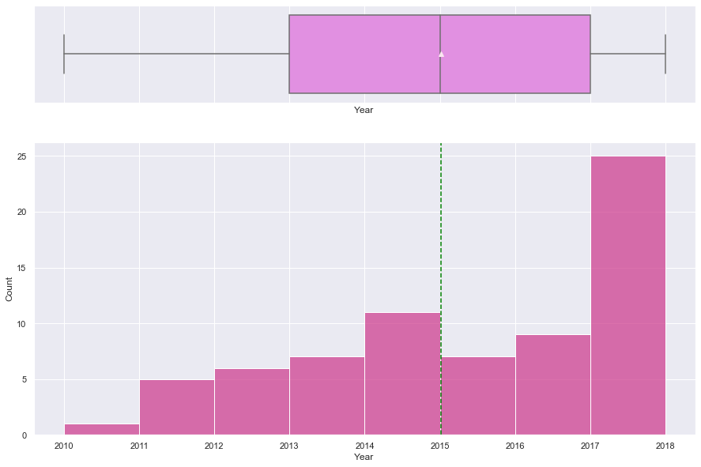

```python
histogram_boxplot(data["Year "])
```

**Observation:**

#### Observations on Electrical conductivity

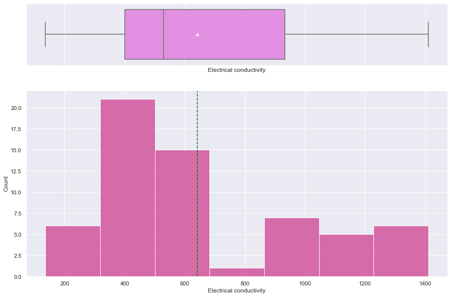

```python
histogram_boxplot(data["Electrical conductivity"])
```

**Observation:**

- This variable is right skewed.
- The majority of the honey sample have an electrical conductivity around 400.

#### Observations on Refractive index

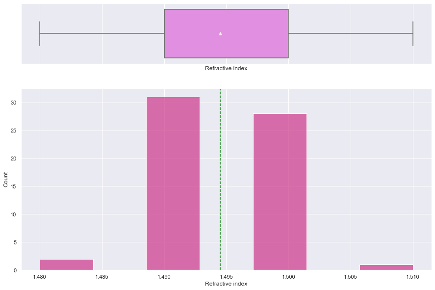

```python
histogram_boxplot(data["Refractive index"])
```

**Observation:**

#### Observations on Water content

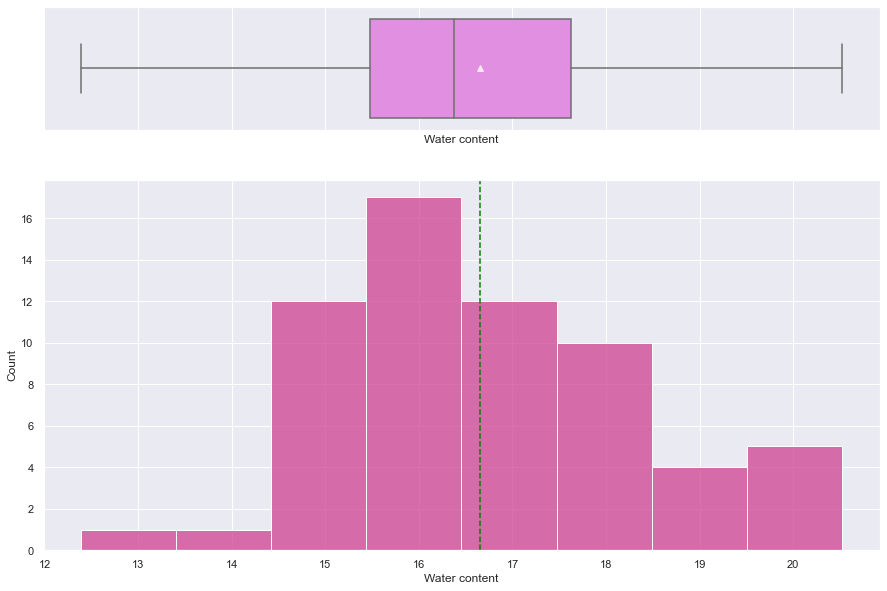

```python
histogram_boxplot(data["Water content"])
```

**Observation:**

- This variable is right skewed.
- The highest samples count account for the water content of 16.

#### Observations on Sensory rating (Target variable)

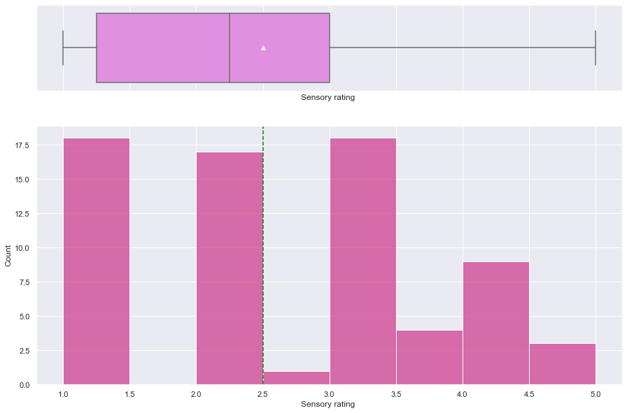

```python
histogram_boxplot(data["Sensory rating "])
```

**Observation:**

- This variables is right skewed.
- We have almost the same number of samples that have a sensory rating between 1.0-1.5 and between 3.0-3.5.

### Univariate analysis (Target variable)

#### Creating plot Sensory rating as a categorical multi-class feature

```python
# Function to create barplots that indicate percentage for each category.

def perc_on_bar(plot, feature):

    total = len(feature) # length of the column
    for p in ax.patches:
        percentage = '{:.1f}%'.format(100 * p.get_height()/total) # percentage of each class of the category
        x = p.get_x() + p.get_width() / 2 - 0.15 # width of the plot
        y = p.get_y() + p.get_height()           # hieght of the plot
        ax.annotate(percentage, (x, y), size = 12) # annotate the percantage
    plt.show() # show the plot
```

#### Observations on Sensory rating

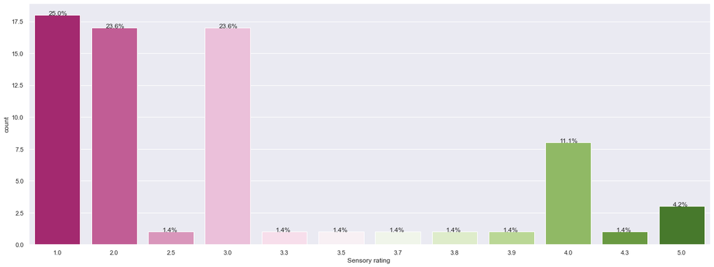

```python
plt.figure(figsize=(22,8))
ax = sns.countplot(data['Sensory rating '],palette="PiYG")
perc_on_bar(ax,data['Sensory rating '])
```

**Observation:**

- Almost half of the honey samples are rated either 1.0 or 2.0.
- 23.6% of the honey samples are rated as 3.0.
- The remained samples which is around 27.8% of the samples are rated 3.0 and higher.

### Lets check out the target variable

```python
data['Sensory rating '].value_counts()
```

```
1.0    18
3.0    17
2.0    17
4.0     8
5.0     3
3.8     1
3.9     1
3.5     1
2.5     1
3.7     1
3.3     1
4.3     1
Name: Sensory rating , dtype: int64
```

### Converting Sensory rating, the target variable, into binary class "Rating"

```python
data['Rating'] = np.where(data['Sensory rating '] >= 4, "premium","non-premium")
print(data['Rating'].value_counts())
```

```
non-premium    60
premium        12
Name: Rating, dtype: int64
```

```python
# Now, we can drop Sensory rating variable
data.drop('Sensory rating ', axis=1, inplace=True)
```

### Bivariate Analysis

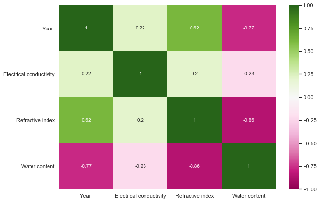

```python
plt.figure(figsize=(10,7))
sns.heatmap(data.corr(),annot=True,vmin=-1,vmax=1,cmap="PiYG")
plt.show()
```

**Observation:**

This heat map demonstrates a strong positive relationship between:

- Refractive index and Year

And a strong negative relationship between:

- Water content and refractive index
- water content and Year

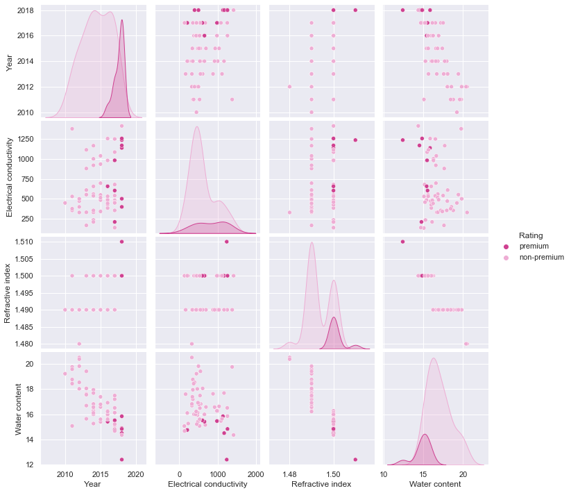

```python
sns.pairplot(data,hue='Rating')
plt.show()
```

**Observation:**

There are overlap in the distribution of variables for both the classes. Let's explore this further using other plots.

### Bivariate Analysis (Numerical)

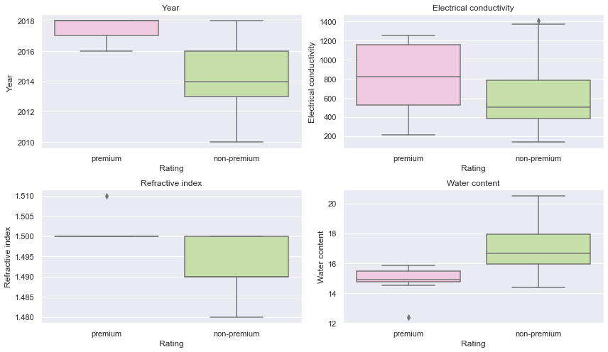

```python
cols = data[
    [
        "Year ",
        "Electrical conductivity",
        "Refractive index",
        "Water content"

    ]
].columns.tolist()

plt.figure(figsize=(12, 7))

for i, variable in enumerate(cols):
    plt.subplot(2, 2, i + 1)
    sns.boxplot(data["Rating"], data[variable], palette="PiYG")
    plt.tight_layout()
    plt.title(variable)
plt.show()
```

**Observation:**

- Honey samples collected between 2017-2018 are premium-quality honey compared to those shich are non-premuim , they are collected in 2016 and back.
- Premium honey samples have higher electrical conductivity than non-premium honey samples.
- Premium honey samples have lower water content compared to non-premium ones.
- Premium honey samples have higher refractive index to non-premium ones.
- It seems like we do not have that much outliers in our data.

### Bivariate Analysis (Categorical Features)

```python
def stacked_plot(x):
    sns.set(palette="PiYG")
    tab1 = pd.crosstab(x, data["Rating"], margins=True)
    print(tab1)
    print("-" * 120)
    tab = pd.crosstab(x, data["Rating"], normalize="index")
    tab.plot(kind="bar", stacked=True, figsize=(10, 5))
    plt.legend(loc="lower left", frameon=False)
    plt.legend(loc="upper left", bbox_to_anchor=(1, 1))
    plt.show()
```

#### Rating vs Botanical origin

```
Rating                         non-premium  premium  All
Botanical origin
Citrus blossoms                          1        0    1
Flowers                                  0        1    1
Flowers and Thorns                      19        1   20
Flowers and Thorns, Kina                 1        0    1
Kina and Flowers                         1        0    1
Kina and Thorns                          0        1    1
Kina, Thyme                              1        0    1
Oak Trees                                4        0    4
Oak Trees, Flowers and Thorns            4        0    4
Orange blossoms                          2        0    2
Thorns                                   4        1    5
Thorns and Oak Trees                     1        0    1
All                                     38        4   42
------------------------------------------------------------------------------------------------------------------------
```

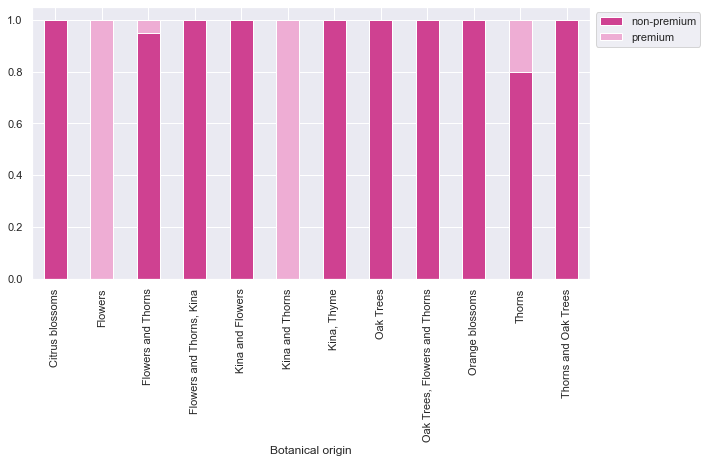

```python
stacked_plot(data["Botanical origin"])
```

**Observation:**

- All mixed Flowers and Thorns honeys are non-premium except for 1 sample.
- blend of Oak Trees, Flowers and Thorns honeys are non-premium honeys.
- All Thorns honeys are non-premium except for 1 sample.
- Also, Oak Trees honeys are non-premium.

## Data Pre-processing

1. Handling missing values
2. Handling data types
3. Handling outliers

#### Lets impute missing values with the mean.

### 1. Handling missing values

```python
from sklearn.impute import SimpleImputer
Imp_mean = SimpleImputer(missing_values=np.nan, strategy='mean')
data["Year "] = Imp_mean.fit_transform(data["Year "].values.reshape(-1, 1) )
data["Electrical conductivity"] = Imp_mean.fit_transform(data["Electrical conductivity"].values.reshape(-1, 1) )
data["Refractive index"] = Imp_mean.fit_transform(data["Refractive index"].values.reshape(-1, 1) )
data["Water content"] = Imp_mean.fit_transform(data["Water content"].values.reshape(-1, 1) )
```

```python
data['Botanical origin'] = data['Botanical origin'].fillna(data['Botanical origin'].mode().iloc[0])
```

```python
data.isnull().sum()
```

```
Year                       0
Botanical origin           0
Electrical conductivity    0
Refractive index           0
Water content              0
Rating                     0
dtype: int64
```

```python
data.head()
```

|  | Year | Botanical origin | Electrical conductivity | Refractive index | Water content | Rating |
| --- | --- | --- | --- | --- | --- | --- |
| 0 | 2017.0 | Flowers and Thorns | 981.0 | 1.50 | 15.46 | premium |
| 1 | 2012.0 | Flowers and Thorns | 330.0 | 1.48 | 20.52 | non-premium |
| 2 | 2014.0 | Oak Trees | 1000.0 | 1.49 | 16.27 | non-premium |
| 3 | 2014.0 | Oak Trees, Flowers and Thorns | 236.0 | 1.50 | 15.26 | non-premium |
| 4 | 2017.0 | Flowers and Thorns | 212.0 | 1.50 | 14.75 | premium |

### 2. Handling data types

#### Converting all object variables into category to reduce the space

```python
data["Botanical origin"]=data["Botanical origin"].astype("category")
```

#### Converting Year to integer

```python
data["Year "]=data["Year "].astype("int")
```

### 3. Handling outliers

It is clearly seen in the boxplots above that the Electrical conductivity has some that need to be handled by capping methods as a preparation step in order to create an accurate model.

#### Handling Electrical conductivity outliers

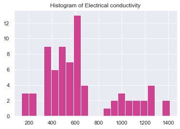

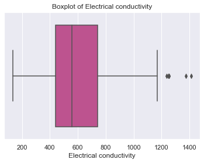

```python
# let's look at Electrical conductivity before caping
plt.hist(data["Electrical conductivity"], 20)
plt.title("Histogram of Electrical conductivity")
plt.show()
sns.boxplot(data["Electrical conductivity"])
plt.title("Boxplot of Electrical conductivity")
plt.show()
```

```python
# Applying capping to handle Electrical conductivity outliers


quartiles = np.quantile(data["Electrical conductivity"][data["Electrical conductivity"].notnull()], [0.25, 0.75])
power_4iqr = 4 * (quartiles[1] - quartiles[0])
print(f"Q1 = {quartiles[0]}, Q3 = {quartiles[1]}, 4*IQR = {power_4iqr}")
outlier_powers = data.loc[
 np.abs(data["Electrical conductivity"] - data["Electrical conductivity"].median()) > power_4iqr, "Electrical conductivity"
]

outlier_powers

data["Electrical conductivity"] = pd.DataFrame(np.where(data["Electrical conductivity"] >  power_4iqr,  power_4iqr,
         (np.where(data["Electrical conductivity"] < quartiles[0],quartiles[0], data["Electrical conductivity"]))), columns=["Electrical conductivity"])
```

```
Q1 = 438.75, Q3 = 741.75, 4*IQR = 1212.0
```

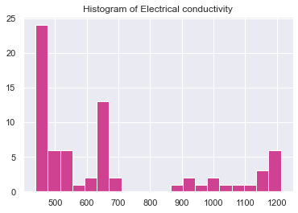

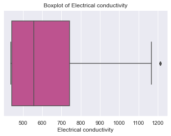

```python
# let's look at Electrical conductivity after caping
plt.hist(data["Electrical conductivity"], 20)
plt.title("Histogram of Electrical conductivity")
plt.show()
sns.boxplot(data["Electrical conductivity"])
plt.title("Boxplot of Electrical conductivity")
plt.show()
```

## Model Building Approach

1. Data preparation
2. Split the data into train and test set.
3. Train models on the training data.
4. Try to improve the model performance using hyperparameter tuning.
5. Test the performance on the test data.
6. Split Data

### Data preparation

#### Create dummies for categorical variables

```python
# creating dummy varibles
dummy_data = pd.get_dummies(
    data,
    columns=[
        "Botanical origin"
    ],
    drop_first=True,
)
dummy_data.head()
```

|  | Year | Electrical conductivity | Refractive index | Water content | Rating | Botanical origin_Flowers | Botanical origin_Flowers and Thorns | Botanical origin_Flowers and Thorns, Kina | Botanical origin_Kina and Flowers | Botanical origin_Kina and Thorns | Botanical origin_Kina, Thyme | Botanical origin_Oak Trees | Botanical origin_Oak Trees, Flowers and Thorns | Botanical origin_Orange blossoms | Botanical origin_Thorns | Botanical origin_Thorns and Oak Trees |
| --- | --- | --- | --- | --- | --- | --- | --- | --- | --- | --- | --- | --- | --- | --- | --- | --- |
| 0 | 2017 | 981.00 | 1.50 | 15.46 | premium | 0 | 1 | 0 | 0 | 0 | 0 | 0 | 0 | 0 | 0 | 0 |
| 1 | 2012 | 438.75 | 1.48 | 20.52 | non-premium | 0 | 1 | 0 | 0 | 0 | 0 | 0 | 0 | 0 | 0 | 0 |
| 2 | 2014 | 1000.00 | 1.49 | 16.27 | non-premium | 0 | 0 | 0 | 0 | 0 | 0 | 1 | 0 | 0 | 0 | 0 |
| 3 | 2014 | 438.75 | 1.50 | 15.26 | non-premium | 0 | 0 | 0 | 0 | 0 | 0 | 0 | 1 | 0 | 0 | 0 |
| 4 | 2017 | 438.75 | 1.50 | 14.75 | premium | 0 | 1 | 0 | 0 | 0 | 0 | 0 | 0 | 0 | 0 | 0 |

#### Defining independent and dependent variables

```python
X = dummy_data.drop('Rating', axis=1)
y = dummy_data['Rating'].apply(lambda x : 0 if x=='non-premium' else 1 )
```

### Split Data

```python
# Splitting data into training and test set:
X_train, X_test, y_train, y_test =train_test_split(X, y, test_size=0.3, random_state=1,stratify=y)
print(X_train.shape, X_test.shape)
```

```
(50, 15) (22, 15)
```

```python
y.value_counts(1)
```

```
0    0.833333
1    0.166667
Name: Rating, dtype: float64
```

```python
y_test.value_counts(1)
```

```
0    0.818182
1    0.181818
Name: Rating, dtype: float64
```

### Model evaluation criterion

**Model can make wrong predictions when:**

- Predicting honey sample as premium quality when it is non-premium ,
- Predicting honey as non-premium quality when it is premium.

**Which case is more important?**

- If the model predicts a honey sample is a non-premium , but the sample is premium, then the company will sell premium honey as non-premium and will lose money.
- If the model predicts that a honey sample is a premium honey, but the sample is not premium, then the company will lose its reputation for selling premium honey.

**Which metric is important to optimize?**

- Since the dataset is imbalanced, we will use F1 score needs to be maximized.
- The higher the F1-Score is, the higher the chances for the model to predict both classes correctly would be.

**Let's define function to provide metric scores on train and test set and a function to show confusion matrix so that we do not have use the same code repetitively while evaluating models.**

```python
##  Function to calculate different metric scores of the model - Accuracy, Recall and Precision
def get_metrics_score(model,flag=True):
    '''
    model : classifier to predict values of X

    '''
    # defining an empty list to store train and test results
    score_list=[]

    pred_train = model.predict(X_train)
    pred_test = model.predict(X_test)

    train_acc = model.score(X_train,y_train)
    test_acc = model.score(X_test,y_test)

    train_recall = metrics.recall_score(y_train,pred_train)
    test_recall = metrics.recall_score(y_test,pred_test)

    train_precision = metrics.precision_score(y_train,pred_train)
    test_precision = metrics.precision_score(y_test,pred_test)

    train_f1 = f1_score(y_train,pred_train)
    test_f1 = f1_score(y_test,pred_test)

    score_list.extend((train_acc,test_acc,train_recall,test_recall,train_precision,test_precision, train_f1, test_f1))

    # If the flag is set to True then only the following print statements will be dispayed. The default value is set to True.
    if flag == True:
        print("Accuracy on training set : ",model.score(X_train,y_train))
        print("Accuracy on test set : ",model.score(X_test,y_test))
        print("Recall on training set : ",metrics.recall_score(y_train,pred_train))
        print("Recall on test set : ",metrics.recall_score(y_test,pred_test))
        print("Precision on training set : ",metrics.precision_score(y_train,pred_train))
        print("Precision on test set : ",metrics.precision_score(y_test,pred_test))
        print("F1-Score on training set : ",metrics.f1_score(y_train,pred_train))
        print("F1-Score on test set : ",metrics.f1_score(y_test,pred_test))

    return score_list # returning the list with train and test scores
```

```python
## Function to create confusion matrix
def make_confusion_matrix(model,y_actual,labels=[1, 0]):
    '''
    model : classifier to predict values of X
    y_actual : ground truth

    '''
    y_predict = model.predict(X_test)
    cm=metrics.confusion_matrix( y_actual, y_predict, labels=[0, 1])
    df_cm = pd.DataFrame(cm, index = [i for i in ["Actual - No","Actual - Yes"]],
                  columns = [i for i in ['Predicted - No','Predicted - Yes']])
    group_counts = ["{0:0.0f}".format(value) for value in
                cm.flatten()]
    group_percentages = ["{0:.2%}".format(value) for value in
                         cm.flatten()/np.sum(cm)]
    labels = [f"{v1}\n{v2}" for v1, v2 in
              zip(group_counts,group_percentages)]
    labels = np.asarray(labels).reshape(2,2)
    plt.figure(figsize = (10,7))
    sns.heatmap(df_cm, annot=labels,fmt='')
    plt.ylabel('True label')
    plt.xlabel('Predicted label')
```

### Decision Tree Classifier

```
Accuracy on training set :  1.0
Accuracy on test set :  0.8181818181818182
Recall on training set :  1.0
Recall on test set :  0.75
Precision on training set :  1.0
Precision on test set :  0.5
F1-Score on training set :  1.0
F1-Score on test set :  0.6
```

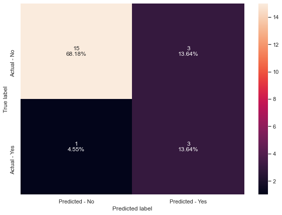

```python
#Fitting the model
d_tree = DecisionTreeClassifier(random_state=1)
d_tree.fit(X_train,y_train)

#Calculating different metrics
get_metrics_score(d_tree)

#Creating confusion matrix
make_confusion_matrix(d_tree,y_test)
```

**Observation:**

- Decision tree is overfitting the training data.
- Let's try hyperparameter tuning and see if the model performance improves.

### Hyperparameter Tuning

```python
#Choose the type of classifier.
dtree_estimator = DecisionTreeClassifier(class_weight={0:0.83,1:0.16},random_state=1)

# Grid of parameters to choose from
parameters = {'max_depth': np.arange(2,30),
              'min_samples_leaf': [1, 2, 5, 7, 10],
              'max_leaf_nodes' : [2, 3, 5, 10,15],
              'min_impurity_decrease': [0.0001,0.001,0.01,0.1]
             }

# Type of scoring used to compare parameter combinations
scorer = metrics.make_scorer(metrics.f1_score)

# Run the grid search
grid_obj = GridSearchCV(dtree_estimator, parameters, scoring=scorer,n_jobs=-1)
grid_obj = grid_obj.fit(X_train, y_train)

# Set the clf to the best combination of parameters
dtree_estimator = grid_obj.best_estimator_

# Fit the best algorithm to the data.
dtree_estimator.fit(X_train, y_train)
```

```
DecisionTreeClassifier(class_weight={0: 0.83, 1: 0.16}, max_depth=3,
                       max_leaf_nodes=5, min_impurity_decrease=0.0001,
                       random_state=1)
```

```
Accuracy on training set :  0.96
Accuracy on test set :  0.9090909090909091
Recall on training set :  0.75
Recall on test set :  0.75
Precision on training set :  1.0
Precision on test set :  0.75
F1-Score on training set :  0.8571428571428571
F1-Score on test set :  0.75
```

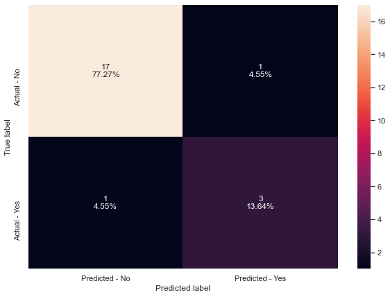

```python
get_metrics_score(dtree_estimator)

make_confusion_matrix(dtree_estimator,y_test)
```

**Observation:**

- The overfitting on the training set has reduced and the test f1-score has also increased.
- Let's try some other models.

### Random Forest Classifier

```python
#Fitting the model
rf_estimator = RandomForestClassifier(random_state=1)
rf_estimator.fit(X_train,y_train)

#Calculating different metrics
get_metrics_score(rf_estimator)

#Creating confusion matrix
make_confusion_matrix(rf_estimator,y_test)
```

[output not shown]

```
Accuracy on training set :  1.0
Accuracy on test set :  0.9090909090909091
Recall on training set :  1.0
Recall on test set :  1.0
Precision on training set :  1.0
Precision on test set :  0.6666666666666666
F1-Score on training set :  1.0
F1-Score on test set :  0.8
```

**Observation:**

- Random Forest is overfitting the training data.
- Let's try hyperparameter tuning and see if the model performance improves.

### Hyperparameter Tuning

```python
# Choose the type of classifier.
rf_tuned = RandomForestClassifier(class_weight={0:0.83,1:0.16},random_state=1,oob_score=True,bootstrap=True)

parameters = {
                'max_depth': list(np.arange(5,30,5)) + [None],
                'max_features': ['sqrt','log2',None],
                'min_samples_leaf': np.arange(1,15,5),
                'min_samples_split': np.arange(2, 20, 5),
                'n_estimators': np.arange(10,110,10)}


# Type of scoring used to compare parameter combinations
scorer = metrics.make_scorer(metrics.f1_score)

# Run the grid search
grid_obj = GridSearchCV(rf_tuned, parameters, scoring=scorer, cv=5,n_jobs=-1)
grid_obj = grid_obj.fit(X_train, y_train)

# Set the clf to the best combination of parameters
rf_tuned = grid_obj.best_estimator_

# Fit the best algorithm to the data.
rf_tuned.fit(X_train, y_train)
```

```
RandomForestClassifier(class_weight={0: 0.83, 1: 0.16}, max_depth=5,
                       max_features=None, min_samples_split=7, n_estimators=70,
                       oob_score=True, random_state=1)
```

```
Accuracy on training set :  0.94
Accuracy on test set :  0.9090909090909091
Recall on training set :  0.75
Recall on test set :  0.75
Precision on training set :  0.8571428571428571
Precision on test set :  0.75
F1-Score on training set :  0.7999999999999999
F1-Score on test set :  0.75
```

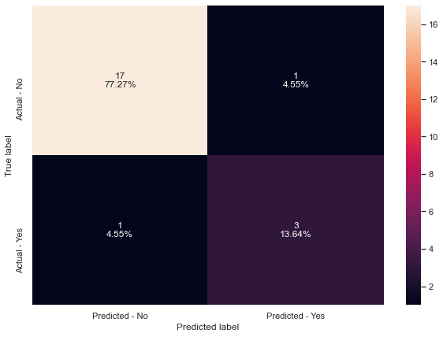

```python
#Calculating different metrics
get_metrics_score(rf_tuned)

#Creating confusion matrix
make_confusion_matrix(rf_tuned,y_test)
```

**Observation:**

- The overfitting on the training set has reduced but test f1-score has decreased. Let's try some other models.

### Bagging Classifier

```
Accuracy on training set :  1.0
Accuracy on test set :  0.8181818181818182
Recall on training set :  1.0
Recall on test set :  0.75
Precision on training set :  1.0
Precision on test set :  0.5
F1-Score on training set :  1.0
F1-Score on test set :  0.6
```

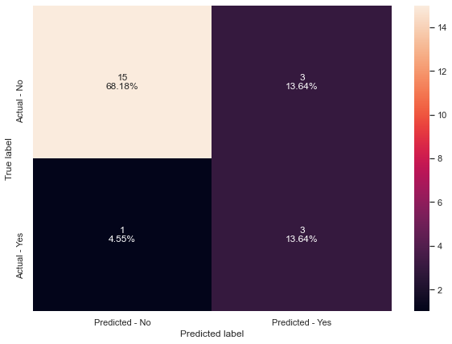

```python
#Fitting the model
bagging_classifier = BaggingClassifier(random_state=1)
bagging_classifier.fit(X_train,y_train)

#Calculating different metrics
get_metrics_score(bagging_classifier)

#Creating confusion matrix
make_confusion_matrix(bagging_classifier,y_test)
```

**Observation:**

Bagging is overfitting the training data. Let's try hyperparameter tuning and see if the model performance improves.

### Hyperparameter Tuning

```python
# Choose the type of classifier.
bagging_estimator_tuned = BaggingClassifier(random_state=1)

# Grid of parameters to choose from
parameters = {'max_samples': [0.7,0.8,0.9,1],
              'max_features': [0.7,0.8,0.9,1],
              'n_estimators' : [10,20,30,40,50],
             }

# Type of scoring used to compare parameter combinations
scorer = metrics.make_scorer(metrics.f1_score)

# Run the grid search
grid_obj = GridSearchCV(bagging_estimator_tuned, parameters, scoring=scorer,cv=5)
grid_obj = grid_obj.fit(X_train, y_train)

# Set the clf to the best combination of parameters
bagging_estimator_tuned = grid_obj.best_estimator_

# Fit the best algorithm to the data.
bagging_estimator_tuned.fit(X_train, y_train)
```

```
BaggingClassifier(max_features=0.7, max_samples=0.7, random_state=1)
```

```python
#Calculating different metrics
get_metrics_score(bagging_estimator_tuned)

#Creating confusion matrix
make_confusion_matrix(bagging_estimator_tuned,y_test)
```

[output not shown]

```
Accuracy on training set :  1.0
Accuracy on test set :  0.8636363636363636
Recall on training set :  1.0
Recall on test set :  1.0
Precision on training set :  1.0
Precision on test set :  0.5714285714285714
F1-Score on training set :  1.0
F1-Score on test set :  0.7272727272727273
```

**Observation:**

- The overfitting on the training set in not solved.
- Let's try some other models.

### AdaBoost Classifier

```
Accuracy on training set :  1.0
Accuracy on test set :  0.7272727272727273
Recall on training set :  1.0
Recall on test set :  1.0
Precision on training set :  1.0
Precision on test set :  0.4
F1-Score on training set :  1.0
F1-Score on test set :  0.5714285714285715
```

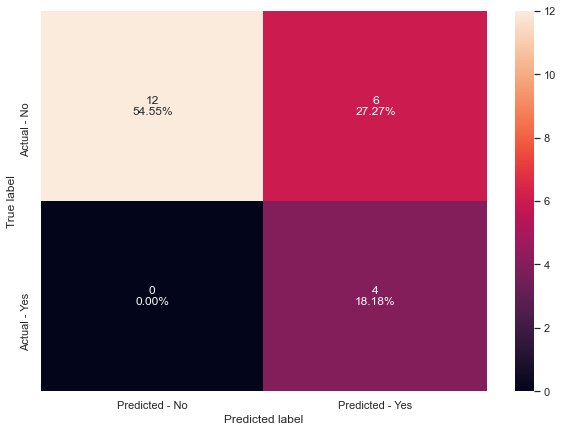

```python
#Fitting the model
ab_classifier = AdaBoostClassifier(random_state=1)
ab_classifier.fit(X_train,y_train)

#Calculating different metrics
get_metrics_score(ab_classifier)

#Creating confusion matrix
make_confusion_matrix(ab_classifier,y_test)
```

**Observation:**

- AdaBoost is overfitting the training data.
- Let's try hyperparameter tuning and see if the model performance improves.

### Hyperparameter Tuning

```python
# Choose the type of classifier.
abc_tuned = AdaBoostClassifier(random_state=1)

# Grid of parameters to choose from
parameters = {
    #Let's try different max_depth for base_estimator
    "base_estimator":[DecisionTreeClassifier(max_depth=1),DecisionTreeClassifier(max_depth=2),
                      DecisionTreeClassifier(max_depth=3)],
    "n_estimators": np.arange(10,110,10),
    "learning_rate":np.arange(0.1,2,0.1)
}

# Type of scoring used to compare parameter  combinations
scorer = metrics.make_scorer(metrics.f1_score)

# Run the grid search
grid_obj = GridSearchCV(abc_tuned, parameters, scoring=scorer,cv=5)
grid_obj = grid_obj.fit(X_train, y_train)

# Set the clf to the best combination of parameters
abc_tuned = grid_obj.best_estimator_

# Fit the best algorithm to the data.
abc_tuned.fit(X_train, y_train)
```

```
AdaBoostClassifier(base_estimator=DecisionTreeClassifier(max_depth=1),
                   learning_rate=1.6, n_estimators=100, random_state=1)
```

```python
#Calculating different metrics
get_metrics_score(abc_tuned)

#Creating confusion matrix
make_confusion_matrix(abc_tuned,y_test)
```

[output not shown]

```
Accuracy on training set :  1.0
Accuracy on test set :  0.9090909090909091
Recall on training set :  1.0
Recall on test set :  1.0
Precision on training set :  1.0
Precision on test set :  0.6666666666666666
F1-Score on training set :  1.0
F1-Score on test set :  0.8
```

**Observation:**

- The overfitting on the training set in not solved.
- Let's try some other models.

### Gradient Boosting Classifier

```python
#Fitting the model
gb_classifier = GradientBoostingClassifier(random_state=1)
gb_classifier.fit(X_train,y_train)

#Calculating different metrics
get_metrics_score(gb_classifier)

#Creating confusion matrix
make_confusion_matrix(gb_classifier,y_test)
```

[output not shown]

```
Accuracy on training set :  1.0
Accuracy on test set :  0.9090909090909091
Recall on training set :  1.0
Recall on test set :  1.0
Precision on training set :  1.0
Precision on test set :  0.6666666666666666
F1-Score on training set :  1.0
F1-Score on test set :  0.8
```

**Observation:**

- GradientBoosting is overfitting the training data.
- Let's try hyperparameter tuning and see if the model performance improves.

### Hyperparameter Tuning

```python
# Choose the type of classifier.
gbc_tuned = GradientBoostingClassifier(init=AdaBoostClassifier(random_state=1),random_state=1)

# Grid of parameters to choose from
parameters = {
    "n_estimators": [100,150,200,250],
    "subsample":[0.8,0.9,1],
    "max_features":[0.7,0.8,0.9,1]
}

# Type of scoring used to compare parameter combinations
scorer = metrics.make_scorer(metrics.f1_score)

# Run the grid search
grid_obj = GridSearchCV(gbc_tuned, parameters, scoring=scorer,cv=5)
grid_obj = grid_obj.fit(X_train, y_train)

# Set the clf to the best combination of parameters
gbc_tuned = grid_obj.best_estimator_

# Fit the best algorithm to the data.
gbc_tuned.fit(X_train, y_train)
```

```
GradientBoostingClassifier(init=AdaBoostClassifier(random_state=1),
                           max_features=0.7, random_state=1, subsample=1)
```

```python
#Calculating different metrics
get_metrics_score(gbc_tuned)

#Creating confusion matrix
make_confusion_matrix(gbc_tuned,y_test)
```

[output not shown]

```
Accuracy on training set :  1.0
Accuracy on test set :  0.9090909090909091
Recall on training set :  1.0
Recall on test set :  1.0
Precision on training set :  1.0
Precision on test set :  0.6666666666666666
F1-Score on training set :  1.0
F1-Score on test set :  0.8
```

**Observation:**

- The overfitting on the training set in not solved.
- Let's try some other models.

### XGBoost Classifier

```python
#Fitting the model
xgb_classifier = XGBClassifier(random_state=1, eval_metric='logloss')
xgb_classifier.fit(X_train,y_train)

#Calculating different metrics
get_metrics_score(xgb_classifier)

#Creating confusion matrix
make_confusion_matrix(xgb_classifier,y_test)
```

[output not shown]

```
Accuracy on training set :  0.96
Accuracy on test set :  0.8636363636363636
Recall on training set :  0.875
Recall on test set :  1.0
Precision on training set :  0.875
Precision on test set :  0.5714285714285714
F1-Score on training set :  0.875
F1-Score on test set :  0.7272727272727273
```

### Hyperparameter Tuning

```python
# Choose the type of classifier.
xgb_tuned = XGBClassifier(random_state=1, eval_metric='logloss')

# Grid of parameters to choose from
parameters = {
    "n_estimators": [10,30,50],
    "scale_pos_weight":[1,2,5],
    "subsample":[0.7,0.9,1],
    "learning_rate":[0.05, 0.1,0.2],
    "colsample_bytree":[0.7,0.9,1],
    "colsample_bylevel":[0.5,0.7,1]
}

# Type of scoring used to compare parameter combinations
scorer = metrics.make_scorer(metrics.f1_score)

# Run the grid search
grid_obj = GridSearchCV(xgb_tuned, parameters,scoring=scorer,cv=5)
grid_obj = grid_obj.fit(X_train, y_train)

# Set the clf to the best combination of parameters
xgb_tuned = grid_obj.best_estimator_

# Fit the best algorithm to the data.
xgb_tuned.fit(X_train, y_train)
```

```
XGBClassifier(base_score=0.5, booster='gbtree', callbacks=None,
              colsample_bylevel=0.7, colsample_bynode=1, colsample_bytree=0.9,
              early_stopping_rounds=None, enable_categorical=False,
              eval_metric='logloss', feature_types=None, gamma=0, gpu_id=-1,
              grow_policy='depthwise', importance_type=None,
              interaction_constraints='', learning_rate=0.05, max_bin=256,
              max_cat_threshold=64, max_cat_to_onehot=4, max_delta_step=0,
              max_depth=6, max_leaves=0, min_child_weight=1, missing=nan,
              monotone_constraints='()', n_estimators=10, n_jobs=0,
              num_parallel_tree=1, predictor='auto', random_state=1, ...)
```

```python
#Calculating different metrics
get_metrics_score(xgb_tuned)

#Creating confusion matrix
make_confusion_matrix(xgb_tuned,y_test)
```

[output not shown]

```
Accuracy on training set :  0.92
Accuracy on test set :  0.8636363636363636
Recall on training set :  1.0
Recall on test set :  1.0
Precision on training set :  0.6666666666666666
Precision on test set :  0.5714285714285714
F1-Score on training set :  0.8
F1-Score on test set :  0.7272727272727273
```

**Observation:**

- XGBoost shows good results

### Stacking Classifier

```python
estimators = [('Random Forest',rf_tuned), ('Gradient Boosting',gbc_tuned), ('Decision Tree',dtree_estimator)]

final_estimator = xgb_tuned

stacking_classifier= StackingClassifier(estimators=estimators,final_estimator=final_estimator)

stacking_classifier.fit(X_train,y_train)
```

```
StackingClassifier(estimators=[('Random Forest',
                                RandomForestClassifier(class_weight={0: 0.83,
                                                                     1: 0.16},
                                                       max_depth=5,
                                                       max_features=None,
                                                       min_samples_split=7,
                                                       n_estimators=70,
                                                       oob_score=True,
                                                       random_state=1)),
                               ('Gradient Boosting',
                                GradientBoostingClassifier(init=AdaBoostClassifier(random_state=1),
                                                           max_features=0.7,
                                                           random_state=1,
                                                           subsample=1)),
                               ('Decision Tree',
                                Deci...
                                                 feature_types=None, gamma=0,
                                                 gpu_id=-1,
                                                 grow_policy='depthwise',
                                                 importance_type=None,
                                                 interaction_constraints='',
                                                 learning_rate=0.05,
                                                 max_bin=256,
                                                 max_cat_threshold=64,
                                                 max_cat_to_onehot=4,
                                                 max_delta_step=0, max_depth=6,
                                                 max_leaves=0,
                                                 min_child_weight=1,
                                                 missing=nan,
                                                 monotone_constraints='()',
                                                 n_estimators=10, n_jobs=0,
                                                 num_parallel_tree=1,
                                                 predictor='auto',
                                                 random_state=1, ...))
```

```python
#Calculating different metrics
get_metrics_score(stacking_classifier)

#Creating confusion matrix
make_confusion_matrix(stacking_classifier,y_test)
```

[output not shown]

```
Accuracy on training set :  0.96
Accuracy on test set :  0.8636363636363636
Recall on training set :  1.0
Recall on test set :  1.0
Precision on training set :  0.8
Precision on test set :  0.5714285714285714
F1-Score on training set :  0.888888888888889
F1-Score on test set :  0.7272727272727273
```

**Observation:**

- Stacking shows good results.

### Comparing all models

```python
# defining list of models
models = [d_tree, dtree_estimator,rf_estimator, rf_tuned, bagging_classifier,bagging_estimator_tuned,
          ab_classifier, abc_tuned, gb_classifier, gbc_tuned, xgb_classifier,xgb_tuned, stacking_classifier]

# defining empty lists to add train and test results
acc_train = []
acc_test = []
recall_train = []
recall_test = []
precision_train = []
precision_test = []
f1_train = []
f1_test = []

# looping through all the models to get the metrics score - Accuracy, Recall and Precision
for model in models:

    j = get_metrics_score(model,False)
    acc_train.append(j[0])
    acc_test.append(j[1])
    recall_train.append(j[2])
    recall_test.append(j[3])
    precision_train.append(j[4])
    precision_test.append(j[5])
    f1_train.append(j[6])
    f1_test.append(j[7])
```

```python
comparison_frame = pd.DataFrame({'Model':['Decision Tree','Tuned Decision Tree','Random Forest','Tuned Random Forest',
                                          'Bagging Classifier','Bagging Classifier Tuned','AdaBoost Classifier','Tuned AdaBoost Classifier',
                                          'Gradient Boosting Classifier', 'Tuned Gradient Boosting Classifier',
                                          'XGBoost Classifier',  'Tuned XGBoost Classifier', 'Stacking Classifier'],
                                          'Train_Accuracy': acc_train,'Test_Accuracy': acc_test,
                                          'Train_Recall':recall_train,'Test_Recall':recall_test,
                                          'Train_Precision':precision_train,'Test_Precision':precision_test,
                                           'Train_F1-Score':f1_train, 'Test_F1-Score':f1_test})

#Sorting models in decreasing order of test recall
comparison_frame.sort_values(by='Test_F1-Score',ascending=False)
```

|  | Model | Train_Accuracy | Test_Accuracy | Train_Recall | Test_Recall | Train_Precision | Test_Precision | Train_F1-Score | Test_F1-Score |
| --- | --- | --- | --- | --- | --- | --- | --- | --- | --- |
| 2 | Random Forest | 1.00 | 0.909091 | 1.000 | 1.00 | 1.000000 | 0.666667 | 1.000000 | 0.800000 |
| 7 | Tuned AdaBoost Classifier | 1.00 | 0.909091 | 1.000 | 1.00 | 1.000000 | 0.666667 | 1.000000 | 0.800000 |
| 8 | Gradient Boosting Classifier | 1.00 | 0.909091 | 1.000 | 1.00 | 1.000000 | 0.666667 | 1.000000 | 0.800000 |
| 9 | Tuned Gradient Boosting Classifier | 1.00 | 0.909091 | 1.000 | 1.00 | 1.000000 | 0.666667 | 1.000000 | 0.800000 |
| 1 | Tuned Decision Tree | 0.96 | 0.909091 | 0.750 | 0.75 | 1.000000 | 0.750000 | 0.857143 | 0.750000 |
| 3 | Tuned Random Forest | 0.94 | 0.909091 | 0.750 | 0.75 | 0.857143 | 0.750000 | 0.800000 | 0.750000 |
| 5 | Bagging Classifier Tuned | 1.00 | 0.863636 | 1.000 | 1.00 | 1.000000 | 0.571429 | 1.000000 | 0.727273 |
| 10 | XGBoost Classifier | 0.96 | 0.863636 | 0.875 | 1.00 | 0.875000 | 0.571429 | 0.875000 | 0.727273 |
| 11 | Tuned XGBoost Classifier | 0.92 | 0.863636 | 1.000 | 1.00 | 0.666667 | 0.571429 | 0.800000 | 0.727273 |
| 12 | Stacking Classifier | 0.96 | 0.863636 | 1.000 | 1.00 | 0.800000 | 0.571429 | 0.888889 | 0.727273 |
| 0 | Decision Tree | 1.00 | 0.818182 | 1.000 | 0.75 | 1.000000 | 0.500000 | 1.000000 | 0.600000 |
| 4 | Bagging Classifier | 1.00 | 0.818182 | 1.000 | 0.75 | 1.000000 | 0.500000 | 1.000000 | 0.600000 |
| 6 | AdaBoost Classifier | 1.00 | 0.727273 | 1.000 | 1.00 | 1.000000 | 0.400000 | 1.000000 | 0.571429 |

**Observations:**

- The highest F1 score on the test set is shown for the Random Forest, Tuned AdaBoost Classifier, Gradient Boosting Classifier, Tuned Gradient Boosting Classifier models but they are overfitting on the training set.
- The best score on both training and test sets belongs to Tuned Decision Tree model.

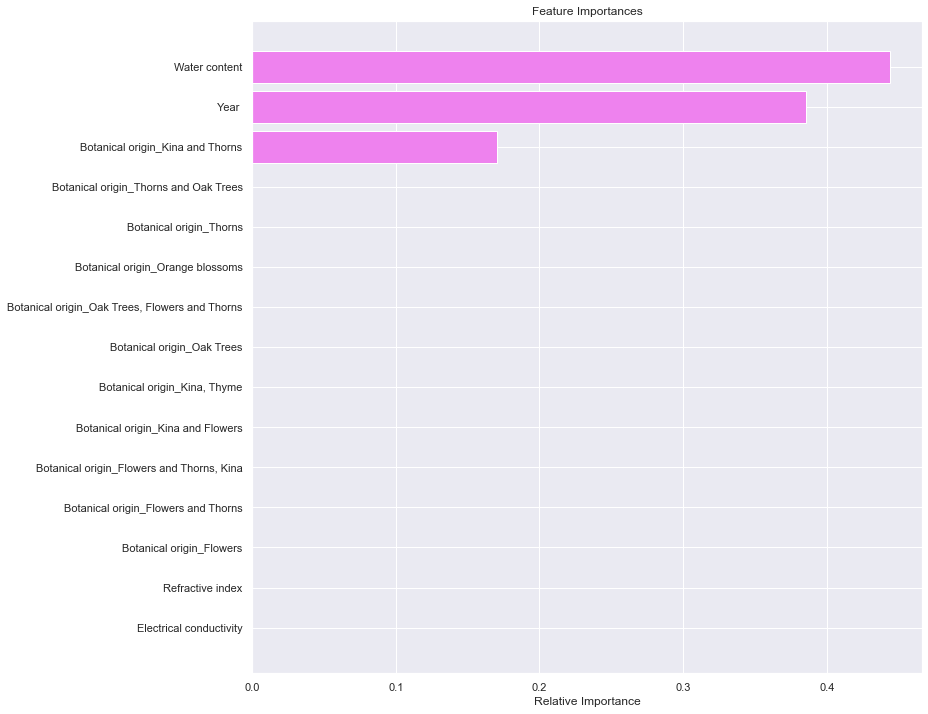

```python
feature_names = X_train.columns
importances = dtree_estimator.feature_importances_
indices = np.argsort(importances)

plt.figure(figsize=(12,12))
plt.title('Feature Importances')
plt.barh(range(len(indices)), importances[indices], color='violet', align='center')
plt.yticks(range(len(indices)), [feature_names[i] for i in indices])
plt.xlabel('Relative Importance')
plt.show()
```

**Observation:**

- "Water content" is the most important feature in identifying premium rated honey followed by "Year" and "Botanical oringin_kina and Thorns" .

## Conclusion:

After all, we can assume that the premium rated honey has the following features in comparison to the non-premium honey:

- Less water content.
- Recently collected.
- Botanical origin of kina and Thorns.

The Water content" is the most important feature in identifying premium rated honey followed by "Year" and "Botanical oringin_kina and Thorns".

Based on the results of the models' comparision, the Tuned Decision Tree model can be used to identify the premium honey for new honey sample.

This model could be used insted of hiring panels for sensory analysis testing.